# sales data analysis report

```python
import matplotlib
import pandas as pd
import numpy as np
import seaborn as sb
from matplotlib import pyplot as plt
import random as rnd
```

```python
sd=pd.read_csv("Sales.csv") # reading csv file
sd
```

|  | month | order_date | identifier | order_num | sub_order_num | quantity | order_status | manifesttime | sup_name | state | ... | shipping_charges_total | gst | taxable_shipping | shipping_gst_18_percent | meesho_price_plus_shipping_charges_total | tcs_taxable_amount | end_customer_state_new | financial_year | month_number | supplier_id |
| --- | --- | --- | --- | --- | --- | --- | --- | --- | --- | --- | --- | --- | --- | --- | --- | --- | --- | --- | --- | --- | --- |
| 0 | 11/1/2022 | 11/28/2022 | kv4xc | 4.334940e+11 | 433493748710_1 | 1 | Shipped | 11/29/2022 | Turbo Traders | Madhya Pradesh | ... | 0 | 1.05 | 60.000000 | 10.800000 | 274 | 260.952381 | ANDHRA PRADESH | 2022 | 11 | 733069 |
| 1 | 11/1/2022 | 11/2/2022 | kv4xc | 4.565440e+11 | 456544057575_1 | 1 | Delivered | 11/3/2022 | Turbo Traders | Madhya Pradesh | ... | 0 | 1.05 | 59.047619 | 10.628571 | 273 | 260.000000 | ANDHRA PRADESH | 2022 | 11 | 733069 |
| 2 | 11/1/2022 | 11/4/2022 | kv4xc | 8.348670e+11 | 834867460958_1 | 1 | Delivered | 11/5/2022 | Turbo Traders | Madhya Pradesh | ... | 0 | 1.05 | 59.047619 | 10.628571 | 273 | 260.000000 | UTTAR PRADESH | 2022 | 11 | 733069 |
| 3 | 11/1/2022 | 11/29/2022 | kv4xc | 2.551520e+11 | 255151569682_1 | 1 | Shipped | 11/29/2022 | Turbo Traders | Madhya Pradesh | ... | 0 | 1.05 | 60.000000 | 10.800000 | 264 | 251.428571 | KERALA | 2022 | 11 | 733069 |
| 4 | 11/1/2022 | 11/8/2022 | kv4xc | 8.056740e+11 | 805674293744_1 | 1 | rto | 11/8/2022 | Turbo Traders | Madhya Pradesh | ... | 0 | 1.05 | 59.047619 | 10.628571 | 263 | 250.476190 | KERALA | 2022 | 11 | 733069 |
| ... | ... | ... | ... | ... | ... | ... | ... | ... | ... | ... | ... | ... | ... | ... | ... | ... | ... | ... | ... | ... | ... |
| 491 | 1/1/2023 | 1/28/2023 | kv4xc | 5.033090e+11 | 503309473282_1 | 1 | Shipped | 1/29/2023 | Turbo Traders | Madhya Pradesh | ... | 0 | 1.05 | 63.809524 | 11.485714 | 182 | 173.333333 | BIHAR | 2023 | 1 | 733069 |
| 492 | 1/1/2023 | 1/5/2023 | kv4xc | 8.418950e+11 | 841895496191_1 | 1 | rto | 1/6/2023 | Turbo Traders | Madhya Pradesh | ... | 0 | 1.05 | 73.333333 | 13.200000 | 376 | 358.095238 | WEST BENGAL | 2023 | 1 | 733069 |
| 493 | 1/1/2023 | 1/13/2023 | kv4xc | 3.588180e+11 | 358817598782_1 | 1 | Delivered | 1/14/2023 | Turbo Traders | Madhya Pradesh | ... | 0 | 1.05 | 73.333333 | 13.200000 | 286 | 272.380952 | RAJASTHAN | 2023 | 1 | 733069 |
| 494 | 1/1/2023 | 1/28/2023 | kv4xc | 2.689940e+11 | 268994158296_1 | 1 | Shipped | 1/28/2023 | Turbo Traders | Madhya Pradesh | ... | 0 | 1.05 | 63.809524 | 11.485714 | 182 | 173.333333 | RAJASTHAN | 2023 | 1 | 733069 |
| 495 | 1/1/2023 | 1/21/2023 | kv4xc | 2.114660e+11 | 211465971448_1 | 1 | Delivered | 1/23/2023 | Turbo Traders | Madhya Pradesh | ... | 0 | 1.05 | 68.571429 | 12.342857 | 210 | 200.000000 | KARNATAKA | 2023 | 1 | 733069 |

496 rows × 33 columns

```python
sd.columns #display all the colunms of the data set
```

```
Index(['month', 'order_date', 'identifier', 'order_num', 'sub_order_num',
       'quantity', 'order_status', 'manifesttime', 'sup_name', 'state', 'pin',
       'reseller_state', 'reseller_pin', 'end_customer_state',
       'end_customer_pin', 'gstin', 'hsn_code', 'gst_amount', 'gst_rate',
       'meesho_price', 'net_commission', 'commission_gst', 'adj',
       'shipping_charges_total', 'gst', 'taxable_shipping',
       'shipping_gst_18_percent', 'meesho_price_plus_shipping_charges_total',
       'tcs_taxable_amount', 'end_customer_state_new', 'financial_year',
       'month_number', 'supplier_id'],
      dtype='object')
```

```python
len(sd.columns)
```

```
33
```

# Sales data column description

month: This column represents the month in which the order was placed.

order_date: This column represents the date on which the order was placed.

identifier: This column represents a unique identifier for the order.

order_num: This column represents the order number.

sub_order_num: This column represents the sub-order number.

quantity: This column represents the quantity of the product that was ordered.

order_status: This column represents the status of the order.

manifesttime: This column represents the time at which the order was shipped.

sup_name: This column represents the name of the supplier.

state: This column represents the state in which the supplier is located.

pin: This column represents the pin code of the supplier.

reseller_state: This column represents the state in which the reseller is located.

reseller_pin: This column represents the pin code of the reseller.

end_customer_state: This column represents the state in which the end customer is located.

end_customer_pin: This column represents the pin code of the end customer.

gstin: This column represents the GSTIN (Goods and Services Tax Identification Number) of the supplier.

hsn_code: This column represents the Harmonized System of Nomenclature (HSN) code for the product.

gst_amount:

This column represents the GST (Goods and Services Tax) amount.

gst_rate: This column represents the GST rate.

meesho_price: This column represents the price of the product charged by Meesho.

net_commission: This column represents the net commission earned by Meesho.

commission_gst: This column represents the GST on the commission earned by Meesho.

adj: This column represents any adjustment made to the order.

shipping charges_total: This column represents the total shipping charges.

gst: This column represents the GST on the shipping charges.

taxable_shipping: This column represents the taxable shipping amount.

shipping_gst 18 percent:

This column represents the GST on shipping at the rate of 18%.

meesho_price_plus_shipping_charges_total: This column represents the total price of the product and shipping charges charged by Meesho.

tcs_taxable_amount: This column represents the amount on which Tax Collected at Source (TCS) is applicable.

end_customer_state_new: This column represents the new state in which the end customer is located.

financial year: This column represents the financial year in which the order was placed.

month_number: This column represents the number of the month in which the order was placed.

supplier_id: This column represents the ID of the supplier.

# analysis just by seeing data

The given data seems to be related to order details, with columns representing various attributes such as the month and order date, order status, quantity, shipping charges, GST rate, and supplier details. The dataset also includes information related to GST, HSN codes, commissions, and taxes, states and PIN codes of the reseller and end customer.

# Analysis using Pandas and other libraries

```python
sd.info()
```

```
<class 'pandas.core.frame.DataFrame'>
RangeIndex: 496 entries, 0 to 495
Data columns (total 33 columns):
 #   Column                                    Non-Null Count  Dtype
---  ------                                    --------------  -----
 0   month                                     488 non-null    object
 1   order_date                                496 non-null    object
 2   identifier                                496 non-null    object
 3   order_num                                 496 non-null    float64
 4   sub_order_num                             496 non-null    object
 5   quantity                                  496 non-null    int64
 6   order_status                              496 non-null    object
 7   manifesttime                              496 non-null    object
 8   sup_name                                  496 non-null    object
 9   state                                     496 non-null    object
```

[output cut: 25 more lines]

```python
sd.describe()
```

|  | order_num | quantity | pin | reseller_pin | end_customer_pin | hsn_code | gst_amount | gst_rate | meesho_price | net_commission | ... | adj | shipping_charges_total | gst | taxable_shipping | shipping_gst_18_percent | meesho_price_plus_shipping_charges_total | tcs_taxable_amount | financial_year | month_number | supplier_id |
| --- | --- | --- | --- | --- | --- | --- | --- | --- | --- | --- | --- | --- | --- | --- | --- | --- | --- | --- | --- | --- | --- |
| count | 4.960000e+02 | 496.000000 | 496.0 | 316.000000 | 496.000000 | 496.000000 | 496.000000 | 496.0 | 496.000000 | 496.0 | ... | 496.000000 | 496.0 | 4.960000e+02 | 496.000000 | 496.000000 | 496.000000 | 496.000000 | 496.000000 | 496.000000 | 496.0 |
| mean | 5.474138e+11 | 1.028226 | 470004.0 | 529401.142405 | 527325.350806 | 947176.209677 | 14.537903 | 5.0 | 305.213710 | 0.0 | ... | 68.375000 | 0.0 | 1.050000e+00 | 61.964286 | 11.153571 | 301.901210 | 287.524962 | 2022.256048 | 9.020161 | 733069.0 |
| std | 2.654584e+11 | 0.165785 | 0.0 | 178227.521561 | 179472.693521 | 4727.185866 | 9.934550 | 0.0 | 208.621146 | 0.0 | ... | 14.214962 | 0.0 | 6.890332e-15 | 14.575107 | 2.623519 | 208.707723 | 198.769260 | 0.436889 | 4.723421 | 0.0 |
| min | 1.003620e+11 | 1.000000 | 470004.0 | 110008.000000 | 110009.000000 | 940500.000000 | 5.900000 | 5.0 | 124.000000 | 0.0 | ... | 61.000000 | 0.0 | 1.050000e+00 | 35.238095 | 6.342857 | 96.000000 | 91.428571 | 2022.000000 | 1.000000 | 733069.0 |
| 25% | 3.156818e+11 | 1.000000 | 470004.0 | 411044.250000 | 411014.750000 | 940530.000000 | 9.940000 | 5.0 | 208.750000 | 0.0 | ... | 61.000000 | 0.0 | 1.050000e+00 | 58.095238 | 10.457143 | 196.000000 | 186.666667 | 2022.000000 | 1.000000 | 733069.0 |
| 50% | 5.378720e+11 | 1.000000 | 470004.0 | 533224.500000 | 534106.000000 | 950510.000000 | 12.860000 | 5.0 | 270.000000 | 0.0 | ... | 63.000000 | 0.0 | 1.050000e+00 | 58.095238 | 10.457143 | 270.000000 | 257.142857 | 2022.000000 | 12.000000 | 733069.0 |
| 75% | 7.683985e+11 | 1.000000 | 470004.0 | 674260.750000 | 673098.000000 | 950510.000000 | 13.060000 | 5.0 | 274.000000 | 0.0 | ... | 72.000000 | 0.0 | 1.050000e+00 | 64.761905 | 11.657143 | 274.000000 | 260.952381 | 2023.000000 | 12.000000 | 733069.0 |
| max | 9.994300e+11 | 2.000000 | 470004.0 | 854304.000000 | 852122.000000 | 950590.000000 | 92.580000 | 5.0 | 1944.000000 | 0.0 | ... | 164.000000 | 0.0 | 1.050000e+00 | 156.190476 | 28.114286 | 1944.000000 | 1851.428571 | 2023.000000 | 12.000000 | 733069.0 |

8 rows × 21 columns

```python
sd.isnull().sum() # to see number of null values And columns
```

```
month                                         8
order_date                                    0
identifier                                    0
order_num                                     0
sub_order_num                                 0
quantity                                      0
order_status                                  0
manifesttime                                  0
sup_name                                      0
state                                         0
pin                                           0
reseller_state                                0
reseller_pin                                180
end_customer_state                            0
end_customer_pin                              0
gstin                                         0
hsn_code                                      0
gst_amount                                    0
gst_rate                                      0
meesho_price                                  0
net_commission                                0
commission_gst                                0
adj                                           0
shipping_charges_total                        0
gst                                           0
taxable_shipping                              0
shipping_gst_18_percent                       0
meesho_price_plus_shipping_charges_total      0
tcs_taxable_amount                            0
end_customer_state_new                        0
financial_year                                0
month_number                                  0
supplier_id                                   0
dtype: int64
```

```python
sd
```

|  | month | order_date | identifier | order_num | sub_order_num | quantity | order_status | manifesttime | sup_name | state | ... | shipping_charges_total | gst | taxable_shipping | shipping_gst_18_percent | meesho_price_plus_shipping_charges_total | tcs_taxable_amount | end_customer_state_new | financial_year | month_number | supplier_id |
| --- | --- | --- | --- | --- | --- | --- | --- | --- | --- | --- | --- | --- | --- | --- | --- | --- | --- | --- | --- | --- | --- |
| 0 | 11/1/2022 | 11/28/2022 | kv4xc | 4.334940e+11 | 433493748710_1 | 1 | Shipped | 11/29/2022 | Turbo Traders | Madhya Pradesh | ... | 0 | 1.05 | 60.000000 | 10.800000 | 274 | 260.952381 | ANDHRA PRADESH | 2022 | 11 | 733069 |
| 1 | 11/1/2022 | 11/2/2022 | kv4xc | 4.565440e+11 | 456544057575_1 | 1 | Delivered | 11/3/2022 | Turbo Traders | Madhya Pradesh | ... | 0 | 1.05 | 59.047619 | 10.628571 | 273 | 260.000000 | ANDHRA PRADESH | 2022 | 11 | 733069 |
| 2 | 11/1/2022 | 11/4/2022 | kv4xc | 8.348670e+11 | 834867460958_1 | 1 | Delivered | 11/5/2022 | Turbo Traders | Madhya Pradesh | ... | 0 | 1.05 | 59.047619 | 10.628571 | 273 | 260.000000 | UTTAR PRADESH | 2022 | 11 | 733069 |
| 3 | 11/1/2022 | 11/29/2022 | kv4xc | 2.551520e+11 | 255151569682_1 | 1 | Shipped | 11/29/2022 | Turbo Traders | Madhya Pradesh | ... | 0 | 1.05 | 60.000000 | 10.800000 | 264 | 251.428571 | KERALA | 2022 | 11 | 733069 |
| 4 | 11/1/2022 | 11/8/2022 | kv4xc | 8.056740e+11 | 805674293744_1 | 1 | rto | 11/8/2022 | Turbo Traders | Madhya Pradesh | ... | 0 | 1.05 | 59.047619 | 10.628571 | 263 | 250.476190 | KERALA | 2022 | 11 | 733069 |
| ... | ... | ... | ... | ... | ... | ... | ... | ... | ... | ... | ... | ... | ... | ... | ... | ... | ... | ... | ... | ... | ... |
| 491 | 1/1/2023 | 1/28/2023 | kv4xc | 5.033090e+11 | 503309473282_1 | 1 | Shipped | 1/29/2023 | Turbo Traders | Madhya Pradesh | ... | 0 | 1.05 | 63.809524 | 11.485714 | 182 | 173.333333 | BIHAR | 2023 | 1 | 733069 |
| 492 | 1/1/2023 | 1/5/2023 | kv4xc | 8.418950e+11 | 841895496191_1 | 1 | rto | 1/6/2023 | Turbo Traders | Madhya Pradesh | ... | 0 | 1.05 | 73.333333 | 13.200000 | 376 | 358.095238 | WEST BENGAL | 2023 | 1 | 733069 |
| 493 | 1/1/2023 | 1/13/2023 | kv4xc | 3.588180e+11 | 358817598782_1 | 1 | Delivered | 1/14/2023 | Turbo Traders | Madhya Pradesh | ... | 0 | 1.05 | 73.333333 | 13.200000 | 286 | 272.380952 | RAJASTHAN | 2023 | 1 | 733069 |
| 494 | 1/1/2023 | 1/28/2023 | kv4xc | 2.689940e+11 | 268994158296_1 | 1 | Shipped | 1/28/2023 | Turbo Traders | Madhya Pradesh | ... | 0 | 1.05 | 63.809524 | 11.485714 | 182 | 173.333333 | RAJASTHAN | 2023 | 1 | 733069 |
| 495 | 1/1/2023 | 1/21/2023 | kv4xc | 2.114660e+11 | 211465971448_1 | 1 | Delivered | 1/23/2023 | Turbo Traders | Madhya Pradesh | ... | 0 | 1.05 | 68.571429 | 12.342857 | 210 | 200.000000 | KARNATAKA | 2023 | 1 | 733069 |

496 rows × 33 columns

```python
sd.columns
```

```
Index(['month', 'order_date', 'identifier', 'order_num', 'sub_order_num',
       'quantity', 'order_status', 'manifesttime', 'sup_name', 'state', 'pin',
       'reseller_state', 'reseller_pin', 'end_customer_state',
       'end_customer_pin', 'gstin', 'hsn_code', 'gst_amount', 'gst_rate',
       'meesho_price', 'net_commission', 'commission_gst', 'adj',
       'shipping_charges_total', 'gst', 'taxable_shipping',
       'shipping_gst_18_percent', 'meesho_price_plus_shipping_charges_total',
       'tcs_taxable_amount', 'end_customer_state_new', 'financial_year',
       'month_number', 'supplier_id'],
      dtype='object')
```

```python
sd.quantity.value_counts() #number of quatity of products ordered by customers
```

```
1    482
2     14
Name: quantity, dtype: int64
```

```python
# 1.average quantity of ordered product

print("Average quantity of ordered product",sd.quantity.mean())
```

```
Average quantity of ordered product 1.028225806451613
```

```python
# 2.how many orders are placed by customer in jan dec and nov

s=sd.month_number.value_counts()
s.index[0]
s
```

```
12    288
1     127
11     81
Name: month_number, dtype: int64
```

```python
#3. How many orders were shipped

l=sd.loc[sd.order_status=="Shipped"]
len(l)
```

[output not shown]

66 rows × 33 columns

```python
# 3.How many orders were shipped in each state

l=sd.end_customer_state[sd.order_status=="Shipped"]
l.value_counts()
```

```
Andhra Pradesh       8
West Bengal          7
Tamil Nadu           6
Telangana            4
Kerala               4
Karnataka            4
Maharashtra          4
Rajasthan            3
Jammu & Kashmir      3
Uttar Pradesh        3
Assam                2
Bihar                2
Odisha               2
Delhi                2
Jharkhand            2
Puducherry           1
Haryana              1
Punjab               1
Madhya Pradesh       1
telangana            1
Himachal Pradesh     1
Gujarat              1
Uttarakhand          1
Meghalaya            1
Arunachal Pradesh    1
Name: end_customer_state, dtype: int64
```

```python
#5.which supplier has the highest number of Orders

sd.supplier_id.value_counts()
```

```
733069    496
Name: supplier_id, dtype: int64
```

```python
#6.how many order has adj greater than 70

l=sd.loc[sd.adj>70]
print(len(l))
l
```

```
151
```

|  | month | order_date | identifier | order_num | sub_order_num | quantity | order_status | manifesttime | sup_name | state | ... | shipping_charges_total | gst | taxable_shipping | shipping_gst_18_percent | meesho_price_plus_shipping_charges_total | tcs_taxable_amount | end_customer_state_new | financial_year | month_number | supplier_id |
| --- | --- | --- | --- | --- | --- | --- | --- | --- | --- | --- | --- | --- | --- | --- | --- | --- | --- | --- | --- | --- | --- |
| 5 | 11/1/2022 | 11/28/2022 | kv4xc | 4.406220e+11 | 440621895540_1 | 2 | Shipped | 11/29/2022 | Turbo Traders | Madhya Pradesh | ... | 0 | 1.05 | 139.047619 | 25.028571 | 240 | 228.571429 | GUJARAT | 2022 | 11 | 733069 |
| 13 | 11/1/2022 | 11/7/2022 | kv4xc | 4.905530e+11 | 490552548982_4 | 1 | Delivered | 11/8/2022 | Turbo Traders | Madhya Pradesh | ... | 0 | 1.05 | 41.904762 | 7.542857 | 96 | 91.428571 | MADHYA PRADESH | 2022 | 11 | 733069 |
| 17 | 11/1/2022 | 11/1/2022 | kv4xc | 2.256680e+11 | 225667603238_1 | 1 | Delivered | 11/2/2022 | Turbo Traders | Madhya Pradesh | ... | 0 | 1.05 | 56.190476 | 10.114286 | 908 | 864.761905 | MAHARASHTRA | 2022 | 11 | 733069 |
| 18 | 11/1/2022 | 11/2/2022 | kv4xc | 6.059510e+11 | 605950579795_1 | 1 | Delivered | 11/3/2022 | Turbo Traders | Madhya Pradesh | ... | 0 | 1.05 | 72.380952 | 13.028571 | 287 | 273.333333 | ANDAMAN AND NICOBAR ISLANDS | 2022 | 11 | 733069 |
| 27 | 11/1/2022 | 11/16/2022 | kv4xc | 9.930920e+11 | 993092407731_1 | 1 | Delivered | 11/16/2022 | Turbo Traders | Madhya Pradesh | ... | 0 | 1.05 | 69.523810 | 12.514286 | 922 | 878.095238 | ANDHRA PRADESH | 2022 | 11 | 733069 |
| ... | ... | ... | ... | ... | ... | ... | ... | ... | ... | ... | ... | ... | ... | ... | ... | ... | ... | ... | ... | ... | ... |
| 489 | 1/1/2023 | 1/22/2023 | kv4xc | 2.966660e+11 | 296665755133_1 | 1 | Delivered | 1/23/2023 | Turbo Traders | Madhya Pradesh | ... | 0 | 1.05 | 73.333333 | 13.200000 | 376 | 358.095238 | WEST BENGAL | 2023 | 1 | 733069 |
| 490 | 1/1/2023 | 1/21/2023 | kv4xc | 5.012050e+11 | 501205269504_1 | 1 | Delivered | 1/21/2023 | Turbo Traders | Madhya Pradesh | ... | 0 | 1.05 | 64.761905 | 11.657143 | 358 | 340.952381 | MADHYA PRADESH | 2023 | 1 | 733069 |
| 492 | 1/1/2023 | 1/5/2023 | kv4xc | 8.418950e+11 | 841895496191_1 | 1 | rto | 1/6/2023 | Turbo Traders | Madhya Pradesh | ... | 0 | 1.05 | 73.333333 | 13.200000 | 376 | 358.095238 | WEST BENGAL | 2023 | 1 | 733069 |
| 493 | 1/1/2023 | 1/13/2023 | kv4xc | 3.588180e+11 | 358817598782_1 | 1 | Delivered | 1/14/2023 | Turbo Traders | Madhya Pradesh | ... | 0 | 1.05 | 73.333333 | 13.200000 | 286 | 272.380952 | RAJASTHAN | 2023 | 1 | 733069 |
| 495 | 1/1/2023 | 1/21/2023 | kv4xc | 2.114660e+11 | 211465971448_1 | 1 | Delivered | 1/23/2023 | Turbo Traders | Madhya Pradesh | ... | 0 | 1.05 | 68.571429 | 12.342857 | 210 | 200.000000 | KARNATAKA | 2023 | 1 | 733069 |

151 rows × 33 columns

```python
#7.average amount of adj on each order

sd.adj.mean()
```

```
68.375
```

```python
#8.which state has highest and lowest number of orders

l=sd.end_customer_state.value_counts()
lmax=sd.end_customer_state.value_counts().max()
l
      # gives whole list in asending order


print("highest orders : ",l.index[0])
print("lowest orders : ",l.index[-1])
```

[output not shown]

```python
#9.which state has highest number of order delivered

OD=sd.end_customer_state[sd.order_status=="Delivered"]
hOD=OD.value_counts()
print("highest orders : ",hOD.index[0])
hOD
```

```
highest orders :  Karnataka
```

```
Karnataka                      45
Tamil Nadu                     39
Andhra Pradesh                 37
Kerala                         34
Maharashtra                    27
Uttar Pradesh                  21
Telangana                      21
Gujarat                        17
Goa                            10
Meghalaya                       8
Odisha                          8
Madhya Pradesh                  8
West Bengal                     8
Delhi                           5
Chhattisgarh                    5
Rajasthan                       5
Manipur                         4
Assam                           4
Uttarakhand                     4
Haryana                         4
tamilnadu                       3
Punjab                          3
Ap                              2
Jharkhand                       2
Jammu & Kashmir                 2
Others                          2
Tamilnadu                       1
Andaman and Nicobar Islands     1
Mizoram                         1
Puducherry                      1
J&k                             1
Mp                              1
Daman & Diu                     1
Andaman & Nicobar Islands       1
Up                              1
Name: end_customer_state, dtype: int64
```

```python
#10.average gst rate for the products

sd.gst_rate.mean() #gst is same on each order
```

```
5.0
```

```python
#11.maximum ,minimum,average gst amount on products

print("maximum GST Amount : ",sd.gst_amount.max())
print("minimum GST Amount : ",sd.gst_amount.min())
print("Average GST Amount : ",sd.gst_amount.mean())
```

```
maximum GST Amount :  92.58
minimum GST Amount :  5.9
Average GST Amount :  14.537903225806456
```

```python
#12.Average meesho price on each product

print("Average Meesho Price on each product: ", sd.meesho_price.mean())
```

[output not shown]

```python
#13.Maximum taxable charge
print("Maximum taxable charge : ",sd.taxable_shipping.max())

#what was the total taxable amount
print("Total taxable amount : ",sd.tcs_taxable_amount.sum())
```

```
Maximum taxable charge :  156.19047619999998
Total taxable amount :  142612.38094513002
```

```python
#14.what was the most common order status

l=sd.order_status.value_counts()
print(l)
print("most common order status : ",l.index[0])
```

```
Delivered    337
Shipped       66
rto           49
Return        23
Cancelled     15
Exchange       3
Ordered        3
Name: order_status, dtype: int64
most common order status :  Delivered
```

```python
#15.how many times the order was return by the customer

print("order was return by the customer ",len(sd[sd.order_status=="Return"]),"times.")
```

```
order was return by the customer  23 times.
```

```python
#16.display states where order was Cancelled by the customer

l=sd.loc[sd.order_status=="Cancelled"]["end_customer_state"]
l.unique()
```

```
array(['Puducherry', 'Nagaland', 'Bihar', 'Uttar Pradesh', 'Karnataka',
       'Andhra Pradesh', 'Tamil Nadu', 'Telangana', 'Chhattisgarh',
       'Rajasthan', 'Maharashtra'], dtype=object)
```

```python
#17.display statewise  highest to lowest number of orders ordered by the customer

sd["end_customer_state"].value_counts()
```

```
Karnataka                      58
Andhra Pradesh                 51
Tamil Nadu                     50
Kerala                         44
Maharashtra                    35
Uttar Pradesh                  31
Telangana                      31
West Bengal                    25
Gujarat                        18
Odisha                         15
Goa                            12
Meghalaya                      11
Rajasthan                      11
Delhi                          10
Madhya Pradesh                 10
Chhattisgarh                    8
Assam                           8
Bihar                           8
Jammu & Kashmir                 6
Uttarakhand                     6
Jharkhand                       5
Punjab                          5
Haryana                         5
Manipur                         4
Puducherry                      4
Mizoram                         3
tamilnadu                       3
Ap                              3
Himachal Pradesh                2
Nagaland                        2
Others                          2
Andaman and Nicobar Islands     1
telangana                       1
J&k                             1
Chandigarh                      1
Daman & Diu                     1
Tamilnadu                       1
Mp                              1
Up                              1
Andaman & Nicobar Islands       1
Arunachal Pradesh               1
Name: end_customer_state, dtype: int64
```

```python
#18.In dec 2022  total number of order Return

L=sd[(sd.order_status=="Return")&(sd.financial_year==2022)&(sd.month_number==12)]
print("Total number of order Return in december 2022 is: ",len(L))
```

```
Total number of order Return in december 2022 is:  10
```

# Data Cleaning

```python
sd.net_commission.value_counts()#zero "0"--->no net commission earned by meesho
```

```
0    496
Name: net_commission, dtype: int64
```

```python
print(sd.shipping_charges_total.value_counts())# no shipping charges are charged on products
```

```
0    496
Name: shipping_charges_total, dtype: int64
```

```python
sd.commission_gst.value_counts()#contain same value 0--> drop column commission gst
```

```
0    496
Name: commission_gst, dtype: int64
```

```python
newsd=sd.drop(["net_commission","shipping_charges_total","commission_gst"],axis=1)
newsd
```

|  | month | order_date | identifier | order_num | sub_order_num | quantity | order_status | manifesttime | sup_name | state | ... | adj | gst | taxable_shipping | shipping_gst_18_percent | meesho_price_plus_shipping_charges_total | tcs_taxable_amount | end_customer_state_new | financial_year | month_number | supplier_id |
| --- | --- | --- | --- | --- | --- | --- | --- | --- | --- | --- | --- | --- | --- | --- | --- | --- | --- | --- | --- | --- | --- |
| 0 | 11/1/2022 | 11/28/2022 | kv4xc | 4.334940e+11 | 433493748710_1 | 1 | Shipped | 11/29/2022 | Turbo Traders | Madhya Pradesh | ... | 63 | 1.05 | 60.000000 | 10.800000 | 274 | 260.952381 | ANDHRA PRADESH | 2022 | 11 | 733069 |
| 1 | 11/1/2022 | 11/2/2022 | kv4xc | 4.565440e+11 | 456544057575_1 | 1 | Delivered | 11/3/2022 | Turbo Traders | Madhya Pradesh | ... | 62 | 1.05 | 59.047619 | 10.628571 | 273 | 260.000000 | ANDHRA PRADESH | 2022 | 11 | 733069 |
| 2 | 11/1/2022 | 11/4/2022 | kv4xc | 8.348670e+11 | 834867460958_1 | 1 | Delivered | 11/5/2022 | Turbo Traders | Madhya Pradesh | ... | 62 | 1.05 | 59.047619 | 10.628571 | 273 | 260.000000 | UTTAR PRADESH | 2022 | 11 | 733069 |
| 3 | 11/1/2022 | 11/29/2022 | kv4xc | 2.551520e+11 | 255151569682_1 | 1 | Shipped | 11/29/2022 | Turbo Traders | Madhya Pradesh | ... | 63 | 1.05 | 60.000000 | 10.800000 | 264 | 251.428571 | KERALA | 2022 | 11 | 733069 |
| 4 | 11/1/2022 | 11/8/2022 | kv4xc | 8.056740e+11 | 805674293744_1 | 1 | rto | 11/8/2022 | Turbo Traders | Madhya Pradesh | ... | 62 | 1.05 | 59.047619 | 10.628571 | 263 | 250.476190 | KERALA | 2022 | 11 | 733069 |
| ... | ... | ... | ... | ... | ... | ... | ... | ... | ... | ... | ... | ... | ... | ... | ... | ... | ... | ... | ... | ... | ... |
| 491 | 1/1/2023 | 1/28/2023 | kv4xc | 5.033090e+11 | 503309473282_1 | 1 | Shipped | 1/29/2023 | Turbo Traders | Madhya Pradesh | ... | 67 | 1.05 | 63.809524 | 11.485714 | 182 | 173.333333 | BIHAR | 2023 | 1 | 733069 |
| 492 | 1/1/2023 | 1/5/2023 | kv4xc | 8.418950e+11 | 841895496191_1 | 1 | rto | 1/6/2023 | Turbo Traders | Madhya Pradesh | ... | 77 | 1.05 | 73.333333 | 13.200000 | 376 | 358.095238 | WEST BENGAL | 2023 | 1 | 733069 |
| 493 | 1/1/2023 | 1/13/2023 | kv4xc | 3.588180e+11 | 358817598782_1 | 1 | Delivered | 1/14/2023 | Turbo Traders | Madhya Pradesh | ... | 77 | 1.05 | 73.333333 | 13.200000 | 286 | 272.380952 | RAJASTHAN | 2023 | 1 | 733069 |
| 494 | 1/1/2023 | 1/28/2023 | kv4xc | 2.689940e+11 | 268994158296_1 | 1 | Shipped | 1/28/2023 | Turbo Traders | Madhya Pradesh | ... | 67 | 1.05 | 63.809524 | 11.485714 | 182 | 173.333333 | RAJASTHAN | 2023 | 1 | 733069 |
| 495 | 1/1/2023 | 1/21/2023 | kv4xc | 2.114660e+11 | 211465971448_1 | 1 | Delivered | 1/23/2023 | Turbo Traders | Madhya Pradesh | ... | 72 | 1.05 | 68.571429 | 12.342857 | 210 | 200.000000 | KARNATAKA | 2023 | 1 | 733069 |

496 rows × 30 columns

```python
newsd.isnull().sum()# month contain 8 null values
```

```
month                                         8
order_date                                    0
identifier                                    0
order_num                                     0
sub_order_num                                 0
quantity                                      0
order_status                                  0
manifesttime                                  0
sup_name                                      0
state                                         0
pin                                           0
reseller_state                                0
reseller_pin                                180
end_customer_state                            0
end_customer_pin                              0
gstin                                         0
hsn_code                                      0
gst_amount                                    0
gst_rate                                      0
meesho_price                                  0
adj                                           0
gst                                           0
taxable_shipping                              0
shipping_gst_18_percent                       0
meesho_price_plus_shipping_charges_total      0
tcs_taxable_amount                            0
end_customer_state_new                        0
financial_year                                0
month_number                                  0
supplier_id                                   0
dtype: int64
```

```python
sd1 = newsd.dropna(subset=["month"]) # deleting all the 8 null value rows fron the dataset
sd1
```

|  | month | order_date | identifier | order_num | sub_order_num | quantity | order_status | manifesttime | sup_name | state | ... | adj | gst | taxable_shipping | shipping_gst_18_percent | meesho_price_plus_shipping_charges_total | tcs_taxable_amount | end_customer_state_new | financial_year | month_number | supplier_id |
| --- | --- | --- | --- | --- | --- | --- | --- | --- | --- | --- | --- | --- | --- | --- | --- | --- | --- | --- | --- | --- | --- |
| 0 | 11/1/2022 | 11/28/2022 | kv4xc | 4.334940e+11 | 433493748710_1 | 1 | Shipped | 11/29/2022 | Turbo Traders | Madhya Pradesh | ... | 63 | 1.05 | 60.000000 | 10.800000 | 274 | 260.952381 | ANDHRA PRADESH | 2022 | 11 | 733069 |
| 1 | 11/1/2022 | 11/2/2022 | kv4xc | 4.565440e+11 | 456544057575_1 | 1 | Delivered | 11/3/2022 | Turbo Traders | Madhya Pradesh | ... | 62 | 1.05 | 59.047619 | 10.628571 | 273 | 260.000000 | ANDHRA PRADESH | 2022 | 11 | 733069 |
| 2 | 11/1/2022 | 11/4/2022 | kv4xc | 8.348670e+11 | 834867460958_1 | 1 | Delivered | 11/5/2022 | Turbo Traders | Madhya Pradesh | ... | 62 | 1.05 | 59.047619 | 10.628571 | 273 | 260.000000 | UTTAR PRADESH | 2022 | 11 | 733069 |
| 3 | 11/1/2022 | 11/29/2022 | kv4xc | 2.551520e+11 | 255151569682_1 | 1 | Shipped | 11/29/2022 | Turbo Traders | Madhya Pradesh | ... | 63 | 1.05 | 60.000000 | 10.800000 | 264 | 251.428571 | KERALA | 2022 | 11 | 733069 |
| 4 | 11/1/2022 | 11/8/2022 | kv4xc | 8.056740e+11 | 805674293744_1 | 1 | rto | 11/8/2022 | Turbo Traders | Madhya Pradesh | ... | 62 | 1.05 | 59.047619 | 10.628571 | 263 | 250.476190 | KERALA | 2022 | 11 | 733069 |
| ... | ... | ... | ... | ... | ... | ... | ... | ... | ... | ... | ... | ... | ... | ... | ... | ... | ... | ... | ... | ... | ... |
| 491 | 1/1/2023 | 1/28/2023 | kv4xc | 5.033090e+11 | 503309473282_1 | 1 | Shipped | 1/29/2023 | Turbo Traders | Madhya Pradesh | ... | 67 | 1.05 | 63.809524 | 11.485714 | 182 | 173.333333 | BIHAR | 2023 | 1 | 733069 |
| 492 | 1/1/2023 | 1/5/2023 | kv4xc | 8.418950e+11 | 841895496191_1 | 1 | rto | 1/6/2023 | Turbo Traders | Madhya Pradesh | ... | 77 | 1.05 | 73.333333 | 13.200000 | 376 | 358.095238 | WEST BENGAL | 2023 | 1 | 733069 |
| 493 | 1/1/2023 | 1/13/2023 | kv4xc | 3.588180e+11 | 358817598782_1 | 1 | Delivered | 1/14/2023 | Turbo Traders | Madhya Pradesh | ... | 77 | 1.05 | 73.333333 | 13.200000 | 286 | 272.380952 | RAJASTHAN | 2023 | 1 | 733069 |
| 494 | 1/1/2023 | 1/28/2023 | kv4xc | 2.689940e+11 | 268994158296_1 | 1 | Shipped | 1/28/2023 | Turbo Traders | Madhya Pradesh | ... | 67 | 1.05 | 63.809524 | 11.485714 | 182 | 173.333333 | RAJASTHAN | 2023 | 1 | 733069 |
| 495 | 1/1/2023 | 1/21/2023 | kv4xc | 2.114660e+11 | 211465971448_1 | 1 | Delivered | 1/23/2023 | Turbo Traders | Madhya Pradesh | ... | 72 | 1.05 | 68.571429 | 12.342857 | 210 | 200.000000 | KARNATAKA | 2023 | 1 | 733069 |

488 rows × 30 columns

```python
sd1.isnull().sum() # all null value rows from month is removed
```

```
month                                         0
order_date                                    0
identifier                                    0
order_num                                     0
sub_order_num                                 0
quantity                                      0
order_status                                  0
manifesttime                                  0
sup_name                                      0
state                                         0
pin                                           0
reseller_state                                0
reseller_pin                                177
end_customer_state                            0
end_customer_pin                              0
gstin                                         0
hsn_code                                      0
gst_amount                                    0
gst_rate                                      0
meesho_price                                  0
adj                                           0
gst                                           0
taxable_shipping                              0
shipping_gst_18_percent                       0
meesho_price_plus_shipping_charges_total      0
tcs_taxable_amount                            0
end_customer_state_new                        0
financial_year                                0
month_number                                  0
supplier_id                                   0
dtype: int64
```

```python
#putting random values in place of null values in "reseller_pin" column

minrsl=sd1.	reseller_pin.min()
maxrsl=sd1.	reseller_pin.max()
randrsl=rnd.randrange(int(minrsl),int(maxrsl))
sd1["reseller_pin"].fillna(randrsl,inplace=True)
```

```python
sd1.isnull().sum() #all null values are filled by random values
```

```
month                                       0
order_date                                  0
identifier                                  0
order_num                                   0
sub_order_num                               0
quantity                                    0
order_status                                0
manifesttime                                0
sup_name                                    0
state                                       0
pin                                         0
reseller_state                              0
reseller_pin                                0
end_customer_state                          0
end_customer_pin                            0
gstin                                       0
hsn_code                                    0
gst_amount                                  0
gst_rate                                    0
meesho_price                                0
adj                                         0
gst                                         0
taxable_shipping                            0
shipping_gst_18_percent                     0
meesho_price_plus_shipping_charges_total    0
tcs_taxable_amount                          0
end_customer_state_new                      0
financial_year                              0
month_number                                0
supplier_id                                 0
dtype: int64
```

```python
sd1.duplicated().unique()# no duplicate value is present in data
```

```
array([False])
```

# Matplotlib

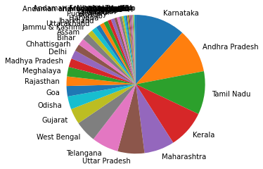

```python
#1.which state had the highest and lowest number of orders,plot on a pie chart

l=sd.end_customer_state.value_counts()
plt.pie(l,labels=l.index,startangle=90,counterclock=False);
plt.axis('square');
```

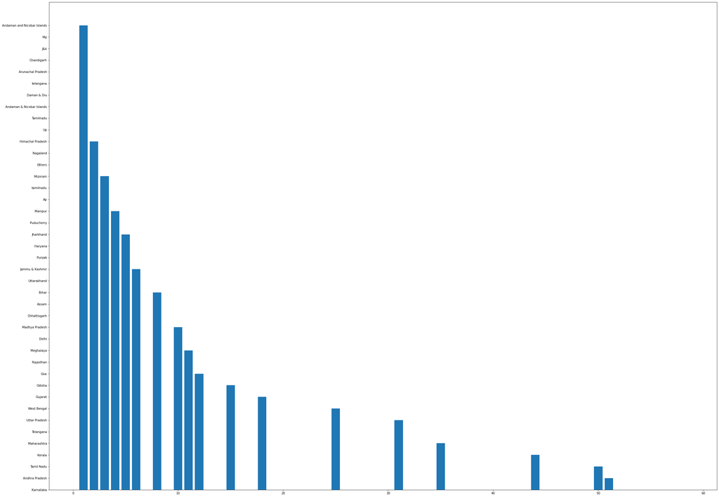

```python
#Same through Bar graph
l=sd.end_customer_state.value_counts()
labels=l.index
# plt.xlabel("count",fontsize=16,labelpad=20);
# plt.ylabel("State",fontsize=16,labelpad=20);
plt.figure(figsize=(40,30));
plt.bar(l,labels);
```

```
12    288
1     127
11     81
Name: month_number, dtype: int64
```

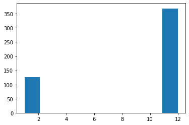

```python
# 2.number of orders placed in each month

ordmnth=sd.month_number
print(sd.month_number.value_counts())
plt.hist(ordmnth)
```

```
<BarContainer object of 15 artists>
```

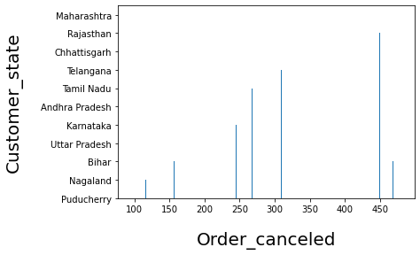

```python
# 3. display states where order was Cancelled by the customer

nsd=sd.loc[sd.order_status=="Cancelled"]["end_customer_state"]
nsd
OC=nsd.index
plt.xlabel("Order_canceled",fontsize=20,labelpad=20)
plt.ylabel("Customer_state",fontsize=20,labelpad=20)
plt.bar(OC,nsd)
```

```
([0, 1, 2, 3, 4, 5, 6, 7, 8, 9, 10],
 <a list of 11 Text major ticklabel objects>)
```

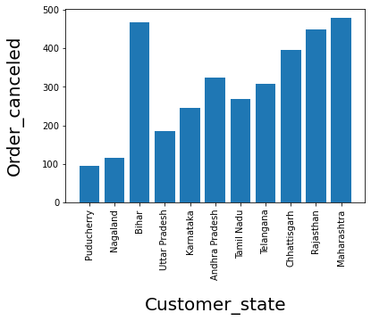

```python
# 4. display states where order was Cancelled by the customer
nsd=sd.loc[sd.order_status=="Cancelled"]["end_customer_state"]
nsd
OC=nsd.index
plt.xlabel("Customer_state",fontsize=20,labelpad=20)
plt.ylabel("Order_canceled",fontsize=20,labelpad=20)
plt.bar(nsd,OC)
plt.xticks(rotation=90) # to remove overlaping of states 90 degree rotation
```

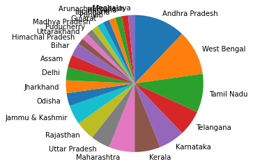

```python
# 5.orders were shipped in each state
l=sd.end_customer_state[sd.order_status=="Shipped"]
s=l.value_counts()

plt.pie(s,labels=s.index,startangle=90,counterclock=False);
plt.axis('square');
```

# seaborn

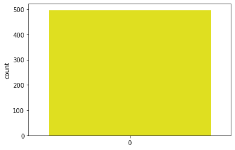

```python
# 6.changes in total shipping charge in different months
sb.countplot(data=sd,x="shipping_charges_total",color= "yellow")
plt.xlabel("")
   # shipping charge is constant in each month
```

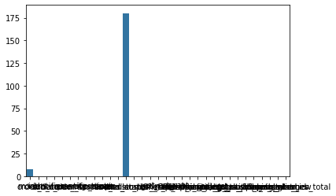

```python
#7. total null values present in data thorugh bar graph
nullcount=sd.isnull().sum()
base_color=sb.color_palette()[0]

sb.barplot(nullcount.index.values,nullcount,color=base_color)
```

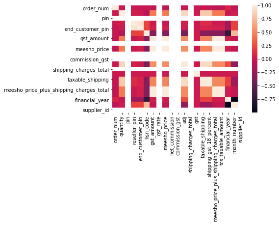

```python
# 8.correlation btween columns

sb.heatmap(sd.corr())
```

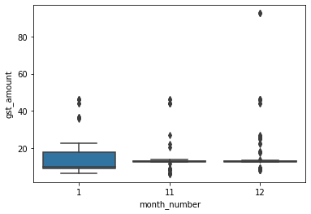

```python
#9.changes in gst amount in different month by box plot

sb.boxplot(x="month_number",y="gst_amount",data=sd)
plt.show()
```

```python
# 10

sb.pairplot(sd,hue="gst_amount")
plt.show()
```

[output not shown]